# Displaying the Amount of Consumption Time in Online Reviews Can Affect Helpful Votes

Converted from PDF `Zhang-ConsumptionTimeHelpfulVotes-2026-JM.pdf` · 16 pages · anchors: page `#pN`, block `#pN-bK`

Page 1

## Displaying the Amount of Consumption Time in Online Reviews Can Affect Helpful Votes

#### Zheng Zhang , Wenjun Zhou , and Michelle Andrews

Abstract Some review platforms display how long reviewers used a product alongside their review. The authors investigate whether doing so translates to more helpful reviews. Using online reviews of video games from a video game platform and leveraging its unique playtime tracking feature, they find that the relationship between the amount of time playing a game before posting a review and the number of helpful votes the review receives follows a U-shaped curve, where shorter and longer playtimes correspond to more votes, while intermediate playtimes correspond to fewer votes. How displayed consumption time affects consumer expectations potentially explains this relationship. The less time reviewers spend consuming a product, the lower others’ expectations of review helpfulness may be and hence the more lenient their judgments. More consumption time may increase these expectations, but extensive consumption time could overcome this higher bar by signaling credibility. Moderation results related to reviewer experience signaling and review or product characteristics, as well as mediation results involving consumer-gifted review awards, help support this context-based expectations account. These results are robust to conditioning out review-, reviewer-, and game-level factors, sample matching, and other settings. The findings have implications for reducing the asymmetric information problem, managing expectations, and optimizing reviews.

Keywords online word of mouth (eWOM), review helpfulness, entropy matching, review platform, video games

Online supplement: https://doi.org/10.1177/00222429251321370

Submitted January 19, 2022

Several review platforms display how long reviewers used a product or service alongside their review. Booking.com includes how long reviewers stayed at lodgings, Yelp indicates how many times reviewers visited businesses, Glassdoor shows how long reviewers worked for employers, Steam reports how long reviewers played video games, and Capterra shows how long reviewers used software programs. Some managers and practitioners endorse this review feature for its potential to add a layer of trust, show the complete user experience, and distinguish between evaluations provided after initial versus extensive use (Baker 2022; Broekhuijsen 2019). Others are more circumspect, worrying that consumers may mistake common reviewers for professional critics and that waiting to solicit feedback could impoverish content via outdated perspectives or waned enthusiasm (Baker 2022; Raza 2019).

Many review platforms also display helpfulness ratings alongside reviews, showing how many consumers rated a review as helpful, useful, or liked. Such ratings can signal the

endorsement of other consumers and significantly influence the purchase process (Abell, Morgan, and Romero 2024; Chen and Xie 2008; Metzger, Flanagin, and Medders 2010; Mousavi et al. 2024; Varga and Albuquerque 2024). The few studies examining whether consumption time affects consumer perceptions of review helpfulness find a positive link (Kim and Han 2022; Zhang, Sinha, and Wang 2024). Those studies infer product interaction from the amount of time reviewers possessed a product, though, which is a coarser measure of consumption time. How displaying the amount of time that a reviewer spent interacting with the product they review relates to review helpfulness ultimately remains an empirical question.

Zheng Zhang is Assistant Professor, Business School, Soochow University, China (email: zhengzhang@suda.edu.cn). Wenjun Zhou is Lawson Professor of Business, Haslam College of Business, University of Tennessee, Knoxville, USA (email: wzhou4@utk.edu). Michelle Andrews is an independent researcher (email: andr.ngc224@gmail.com).

Article

Journal of Marketing 2026, Vol. 90(1) 91-105 © American Marketing Association 2025

Article reuse guidelines: sagepub.com/journals-permissions DOI: 10.1177/00222429251321370

journals.sagepub.com/home/jmx

Page 2

We propose that displayed consumption time provides context about a reviewer’s evaluation basis that helps consumers calibrate their expectations of review helpfulness. By situating a review within the bounds of the reviewer’s product engagement, displayed consumption time provides contextual relevance. Relative to how much time a reviewer spent interacting with a product, consumer expectations about review helpfulness will be low for lower times and high for higher ones. Consumers will then judge the helpfulness of a review by comparing it against their context-based expectations. Reviews that exceed expectations will lead to higher ratings of helpfulness; those that fall short will engender lower ratings. This process may not produce uniform reactions from consumers but rather may be more complex. In addition, because consumers do not form expectations of helpfulness in a vacuum, their judgments may be further affected by how reviewers signal their experience, as well as product-specific characteristics.

We test these ideas using reviews from the largest online video game distribution platform. Our study leverages a unique feature of the platform that tracks each player’s playtime to quantify consumption time. Because the value of displaying consumption time lies in its potential to influence others’ expectations about how helpful the review will be, we use helpful votes to measure judgments of review helpfulness, following studies that use such votes to infer consumer perceptions of helpfulness (Ghose and Ipeirotis 2011). We find that displaying the amount of consumption time in reviews has a U-shaped association with review helpfulness. The less time reviewers spend playing a game before writing their review, the more their review is associated with helpfulness ratings. As consumption time increases, though, the less reviews are associated with helpfulness ratings. This negative relationship occurs up to a point, after which the more time reviewers play a game before evaluating it, the more their review is linked with helpfulness ratings.

The role that consumption time plays in setting consumer expectations of helpfulness may explain these findings. The amount of time reviewers spent interacting with the product they reviewed is informative of their basis for evaluation. Providing context for the review should influence consumers’ expectations and assessments of review usefulness. Moderation results related to how much experience the reviewer has and characteristics of the reviewed product, as well as mediation results involving consumer emphasis of reviews with awards, provide support for this context-based expectations account. Because unobserved heterogeneity in reviewer traits and experiences may affect their decisions to write reviews and may impact the content of their reviews, we condition out review-level and reviewer-level characteristics inouranalyses toreducetheseendogeneity concerns. Our results are consistent when using sample matching and additional robustness tests.

Our findings contribute to the growing literature on how reviewers’ experience shapes consumer perceptions (Nguyen et al. 2021; Packard and Berger 2017; Yazdani, Gopinath, and Carson 2018). Providing context for a reviewer’s evaluation basis by displaying consumption time is becoming common

among review platforms, and our research clarifies the nuances of this practice. To our knowledge, we are the first to document a relationship between a temporal factor of product experience—product consumption time—and perceptions of review helpfulness. Whereas prior studies use measures of tangential experience such as badges earned or reviews submitted (Hoskins et al. 2021; Sunder, Kim, and Yorkston 2019; Wu, Jin, and Xu 2021), consumption time is specific to the reviewed product and may serve as a more direct and relevant indicator of a reviewer’s evaluation basis.

We capture consumption time (with a system-logged measure of product use as opposed to a proxy or self-reported one), product reviews, and helpfulness perceptions (via the number of helpful votes) in a single, relatively coherent system of products. In contrast to studies that treat experience as binary (reviewers are designated as experts or not), we adopt a continuous measure of consumption time to better investigate the nonlinear relationship between consumption time and helpful votes. While demonstrating the robustness of our findings using sample matching, we leverage a maximum entropy reweighting procedure designed for a continuous treatment variable. Our results help shed light on how displaying consumption time relates to review helpfulness by probing boundary conditions and providing initial evidence that this review feature can impact the helpfulness of reviews through its influence on expectations.

Our findings suggest that displaying how long a reviewer interacted with a product alongside their review can reduce the asymmetric information problem whereby consumers are often unaware of the basis for a reviewer’s evaluation. Indicating consumption time can help review platforms prevent disappointment and promote contentment by managing consumer expectations of review helpfulness. Displayed consumption time could also facilitate better matches between consumers and reviewers based on consumer information needs. Because the helpfulness of reviews appears to differ by the amount of time reviewers spent consuming a product, firms may benefit from being strategic about soliciting feedback, incentivizing reviews, and providing guidelines to reviewers based on their consumption time.

#### How Consumers Evaluate Reviews

Consumers may decide whether a review is helpful by comparing it with their expectations about it (Medin, Goldstone, and Gentner 1993; Ritov 2000). Before reading a review, consumers may anticipate its consequence, such as being more informed. After reading a review, consumers may experience feelings such as excitement to have learned something, disappointment to not have found information they were seeking, or relief to have assuaged their prepurchase concerns. Consumers then compare how they feel after reading a review with how they expected they would feel. Reviews that exceed expectations can lead consumers to rate them as helpful, while reviews that fall short of expectations can lead consumers to judge them as unhelpful.

92 Journal of Marketing 90(1)

Page 3

Various review features can shape expectations about review helpfulness. These include reviewer characteristics such as their gender (Craciun, Zhou, and Shan 2020), geographic location (Todri, Adamopoulos, and Andrews 2022), number of reviews written (Hoskins et al. 2021; Ngo-Ye and Sinha 2014; Nguyen et al. 2021), number of ratings submitted (Sunder, Kim, and Yorkston 2019), ranking (Yazdani, Gopinath, and Carson 2018), and variance in their historical ratings (Wu, Jin, and Xu 2021). Reviewer attributes may signal similarity in tastes, expertise, reputation, and engagement and may affect consumer expectations about review helpfulness by reducing their concerns. For example, consumers trust the reviews of experts due to the belief that they know more (Packard and Berger 2017) and are less biased (Hu, Liu, and Zang 2008). Review characteristics such as length (Yazdani, Gopinath, and Carson 2018), linguistic style (Topaloglu and Dass 2021), energy level (Yin, Bond, and Zhang 2017), and images (Ceylan, Diehl, and Proserpio 2024; Kübler et al. 2024) can also influence expectations by cuing thoroughness and credibility.

Consumption time is another review feature that can guide expectations of helpfulness. Consumption time shows how much time reviewers spent interacting with the product they reviewed and as such is informative about their relative knowledge. It indicates a reviewer’s potential knowledge relative to the amount of time they spent engaging with the product. Consumption time thus provides context for the review by situating it within the bounds of the reviewer’s experience with the product. This contextual relevance can help consumers understand the basis for reviewers’ evaluations, such as how thoroughly they were able to inspect the product and how acquainted they may be with its intricacies (Stang 1975). It can also guide consumer expectations by foreshadowing review content, such as how discriminative, elaborative, or comprehensive a review will be as well as its frame of reference (Kim and Han 2022; Maheswaran 1994; Rocklage, Rucker, and Nordgren 2021; Zhang, Sinha, and Wang 2024). Consumers may accordingly calibrate their expectations of review helpfulness by basing them on consumption time. Relative to how long a reviewer engaged with a product, consumer expectations about review helpfulness will be low for lower times and high for higher ones.

The recency of consumption time as a review feature corresponds with few studies examining its impact. Scholars probing the association between displayed length of hotel stays and review content found that longer stays correlate with lengthier and more detailed reviews, which may lead consumers to perceive them as more authentic (Kim and Han 2022). Whereas Kim and Han (2022) gauge authenticity from the textual content of reviews, we explore review ratings as the next link in the chain of consumer-to-consumer persuasion. Doing so can better capture whether perceptions about reviews translate to actions such as helpful votes, which is important because such votes render perceptions of a review visible to others.

The potential for displayed consumption time to impact helpful votes is hinted at by Zhang, Sinha, and Wang (2024),

who find a positive link between the amount of time reviewers were exposed to a product and how many helpful votes their review received. Zhang, Sinha, and Wang infer product exposure from the time between product shipment and review posting. Interaction amounts can vary between reviewers, though, whereby one reviewer may use a product less than another during the same interval. Moreover, in their review setting, product exposure length was not displayed, so it could not affect consumer expectations of helpfulness. While Zhang, Sinha, and Wang validate their measure of product exposure with self-reported ones in the reviews, self-reported usage correlates only moderately with logged measurements of product use (Parry et al. 2021). Our log-based measure of product use that is displayed in reviews thus constitutes a stronger and observable signal of product interaction.

#### How Displayed Consumption Time in a Product Review Influences Helpful Votes

The amount of displayed consumption time in reviews may differentially impact consumer expectations and evaluations of review helpfulness. Shorter times may engender low expectations of review helpfulness due to consumers’ belief that reviewers lack the depth of knowledge needed to sufficiently form opinions (Nguyen et al. 2021; Rocklage, Rucker, and Nordgren 2021; Yazdani, Gopinath, and Carson 2018). Consumers may believe that effectively evaluating a product requires adequate time to become familiar with it, so the less reviewers engage with a product, the less they can report on it. Consumers may consequently temper their expectations about the helpfulness of a review and judge review quality more leniently. Because lower thresholds are easier to surpass, however, evaluations from reviewers who spend less time interacting with a product may pleasantly surprise consumers who find them to be more informative than expected. By more easily exceeding low expectations, reviews with shorter consumption times may ultimately amass more helpful votes.

Longer amounts of consumption time in reviews may induce high expectations of review helpfulness due to consumers’ belief that reviewers possess the necessary knowledge to effectively evaluate a product. More product knowledge can heighten awareness of attribute differences, facilitate the ability to discern diagnostic characteristics (Alba and Hutchinson 1987), and increase sensitivity to nuances (Hoskins et al. 2021; Johnson and Mervis 1997). Reviewers who have spent more time understanding how to use a product, acquiring the skills specific to the product, and reaching the level of comfort necessary to benefit from the product (Chen and Hitt 2002; Mukherjee and Hoyer 2001) may have more familiarity with its intricacies, gained more mastery over its use, and reflected more on their impressions of it (Chase and Simon 1973). Studies support this expectation, showing how knowledge about a reviewer’s past, such as variance in their historical ratings, can lead consumers to believe a reviewer has greater discrimination abilities (Wu, Jin, and Xu 2021). Consumers may accordingly increase their expectations about

Zhang et al. 93

Page 4

the informativeness of a review and judge its usefulness more strictly. Because higher standards are harder to meet, consumers may find evaluations from reviewers who spent more time with a product to be less helpful than expected. By failing to meet high expectations, reviews with longer consumption times may elicit fewer helpful votes.

While extended consumption times may also raise expectations of review helpfulness, they may simultaneously provide credibility. Extensive product interactions suggest that reviewers experienced the product more thoroughly by having more opportunities to identify issues that are initially less obvious and discover potential problems that may only surface from longer use. Studies support these beliefs, showing how time increases learning chances (Stang 1975) and shifts reviewer focus from initial reactions to refined judgments (Maheswaran 1994). This distinction can reinforce and validate reviewer assessments, helping overcome the very expectations it engenders (Ritov 2000). Because consumers may be comforted by the belief that a reviewer’s feedback is more informed than short- and moderate-term use would allow, they may be more willing to trust that reviewer’s opinion. Studies concur, showing how consumers are more trusting and persuaded when they believe reviewers know more about a product (Gilly et al. 1998; Hoskins et al. 2021; Packard and Berger 2017; Rocklage and Fazio 2020). By relaxing concerns about whether high expectations were met, extensive product interaction times may consequently garner more helpful votes.

H1: There is a U-shaped association between displaying consumption time at the time of review and helpful votes, such that at both low and high amounts of consumption time, helpful votes are high, while at moderate levels of consumption time, helpful votes are low.

#### Factors That Affect the Link Between Displayed Consumption Time and Helpful Votes

Because consumers do not form expectations or make evaluations in a vacuum, and perceptions of review helpfulness depend on review and product attributes (Yazdani, Gopinath, and Carson 2018), factors related to the review and product characteristics may further influence the link between the amount of consumption time displayed in reviews and helpfulness judgments.

Reviewers who appear to provide more information about the reviewed product may boost perceptions of review helpfulness. Because consumers believe longer reviews are more informative, they may assume reviewers with such reviews are more informed (Nguyen et al. 2021; Yazdani, Gopinath, and Carson 2018). Review length has accordingly been found to relate to review helpfulness (Lutz, Pröllochs, and Neumann 2022). Another signal of experience comes from how consumption time is displayed in a review. Some platforms may only show total consumption time without differentiating between that at the time of review versus consumption time accumulated after

the review was written. Distinguishing the amount of time reviewers spent interacting with a product at the time of review can be a stronger signal of a reviewer’s product engagement. Consumers should consequently find reviews to be more helpful when platforms display how much time a reviewer spent interacting with the product at the time of review. Once platforms do so, the review length signal may combine with the more specific display of consumption time to further boost consumer perceptions of review informativeness.

H2a: The U-shaped association between the amount of displayed consumption time in reviews and helpful votes is positively moderated by review length.

H2b: The U-shaped association between the amount of displayed consumption time in reviews and helpful votes is positively moderated by displaying the consumption time at the time of review separately from the total consumption time.

H2c: The U-shaped association between the amount of displayed consumption time in reviews and helpful votes is positively moderated by displaying the consumption time at the time of review separately from the total consumption time especially for longer reviews.

The type of product can also affect the role that review features play in driving review helpfulness (Sun, Han, and Feng 2019; Weathers, Swain, and Grover 2015). For example, products that cost more may induce consumers to value the opinions of those who consumed them more due to the greater financial risks involved. In addition, higher-cost products can engender perceptions of higher quality, which consumers may seek to verify from reviews, leading them to be more reliant on such reviews.

H3: The U-shaped association between the amount of displayed consumption time in reviews and helpful votes is positively moderated by product cost.

#### Data Empirical Context

We leverage the video game industry, which is a large and growing market, releasing more than 2,000 unique video games and generating revenues exceeding $35 billion in 2019 in the United States (Entertainment Software Association 2020). Our dataset comes from Steam, the largest online video game distribution platform, to which more than 12 million gamers log on daily. Gamers can play almost 30,000 video games on Steam, and can also rate video games and read video game reviews. On a game page, consumers can view the overall rating, recent ratings, and reviews from other gamers.

94 Journal of Marketing 90(1)

Page 5

We obtained data from the top 100 most reviewed games by release year from 2017 to 2022 on Steam, for a total of 600 games (Web Appendix A summarizes these games). Using the most reviewed games is ideal because the number of reviews proxies market size, as games with more players tend to garner more reviews. We narrowed our sample to reviews posted within the first 12 months of the release date for each game. This unified time frame helps prevent individual games from dominating the full sample and avoids potential problems such as version changes and player fatigue by having longer observation windows for older games. Our sampling approach also enables us to obtain a good representation of games with a range of review polarity (from overwhelmingly positive to mixed), price (free or pay-to-play), and genres (e.g., role-play, adventure, and online co-op).

Each review displays the reviewer’s username, review text, when they reviewed the game (time stamp), and the number of helpful votes their review received to date, as shown in Figure 1. A unique feature of the Steam platform is that in March 2009 it started tracking each gamer’s playtime in each game played. This tracked playtime is displayed in the gamer’s review and shows the total amount of time spent playing the reviewed game to date. Beginning in late September 2019, the Steam platform further broke down this displayed playtime feature to show not only the total time played of a reviewed game by an individual gamer to date, but also the amount of time the gamer had played the game they reviewed at the time of their review. Taking the review in Figure 1 as an example, where the gamer posted a review of a game after playing it for 7.1 hours and continued playing it for another 46.1 hours after posting their review, the playtime displayed on the review would be 7.1 hours at review and 53.2 hours total.

#### Measures

Dependent and independent variables. Our dependent variable is the perceived helpfulness of a review (Helpful), which we operationalize as the number of helpful votes a review receives. Consumers can indicate whether they found a review to be helpful by voting for it as such and can only cast one vote per review.

Our independent variable is a reviewer’s product consumption time (ConsTime), which we operationalize as the number of game minutes played at the time of posting the game review. We measure consumption time at the time of the review instead of the total time played because a reviewer forms their impression of a product based on their experience with the product up until the time they post their review about it.

Moderator variables. Because perceptions of review helpfulness may be further affected by review and product attributes, we consider several factors. For example, a common approach to signaling experience is via the length of the review. We operationalize review length as the word count of the review after

excluding stopwords (ReviewLength). The displayed amount of playtime at review is another signal of reviewer experience. Recall that Steam began separating the playtime displayed in a review into that of the playtime at review and that of the total playtime on September 19, 2019. To capture the extent to which playtime at review may further affect the link between consumption time and helpful votes, we code a dummy variable named Separate, which takes the value of 1 if the review is posted on or after September 19, 2019, and 0 otherwise.

At the product level, we consider the monetary cost of the game. Some games are released as free to play, whereby consumers can play a game without paying upfront. Such games may be inherently different from pay-to-play games. That is, because higher-cost games may pose greater financial risk to consumers, consumers may value reviews of such games differently. We therefore code a binary variable called Free2Play, which takes the value of 1 if the game is free to play and 0 otherwise.

Control variables. Consumers read online reviews to acquire more information and reduce uncertainty about the purchase they are considering. Consumers may be more likely to appreciate information the newer it is. That is, information may be more helpful the sooner consumers can acquire it. We therefore consider how early a review is posted, because consumers may perceive earlier reviews to be more helpful given the dearth of available information about a newer game. We operationalize the (lack of) temporal novelty as the number of weeks since the game release when the review was posted (WeeksSinceRelease).

We control for the content similarity of a review compared with other recently posted reviews. Specifically, we operationalize a variable, Similarity, as the average cosine similarity of a review with the most recent 20 reviews posted by other reviewers prior to the focal review. The cosine similarity has a range of −1 to 1, with 1 indicating the most similar and −1 indicating the least similar. The first 20 reviews of any game were assigned a similarity score of 0, indicating that they were all novel.

Because reviews may vary in their amount of emotion and judgment, we include the review sentiment polarity (Sentiment) and subjectivity (Subjectivity) of the review text to account for these factors, following Akbarabadi and Hosseini (2020) and Rocklage, Rucker, and Nordgren (2021). We operationalize Sentiment and Subjectivity as the polarity and subjectivity score of the text using a lexicon-based approach available in a Python package called TextBlob (Loria 2021, Version 0.17.1). The sentiment polarity and subjectivity scores of a review are calculated as the average score among the polarized words. The calculated polarity ranges from −1 to 1 (negative to positive) while the subjectivity ranges from 0 to 1 (objective to subjective). While review length may indicate the quantity of information provided in a review, it is possible that some information is irrelevant to information seekers. In other words, the content of the

Zhang et al. 95

Page 6

[figure not shown]

NOTE: figure/graphic rendered as an image from the PDF; its content is not machine-readable text. Caption (if any) follows as the next block.

review could also have an impact on the perceived helpfulness. We therefore measure Specificity, which is operationalized as the ratio between the number of words that represent specific entity names, quantitative values, and times/dates and the total number of words in the review (Hope, Hu, and Lu 2016). We employed a Python package called spaCy (Honnibal et al. 2020, Version 3.7.5) to extract the entity names. To account for potential differences in reviews based on the day of the week they were written, we control for whether a review was written on a weekend (Weekend) with a binary variable coded as 1 if the review was posted on a Saturday or Sunday and 0 otherwise, similar to Li, Gopinath, and Carson (2022). We also control for the possibility that some reviews may attract more attention than others using the number of replies the review receives (NReplies). We further control for reviewer-level factors including the number of games owned (NGames), number of reviews written (NReviews), number of badges owned (NBadges), and number of friends on Steam (NFriends).

Some video games are designed to be played with others, whereas other games are designed for solo play. On the Steam platform, consumers can tag games with a variety of terms they believe best describe the game. Thus, we categorize games by player modality into a variable called GroupCons, which is coded as 1 if the game received more “multiplayer” than “single player” tags, and 0 otherwise. This variable represents the collectively perceived categories of each game from the community perspective, which we control for. We also control for the playtime differences among games by collecting the time to beat each game (Time2Beat) from a third-party website, HowLongToBeat (https://howlongtobeat.com/), which catalogs the average time that gamers report it takes them to play a game from start to finish. Together, these factors related to review-, reviewer-, and game-level characteristics help reduce endogeneity concerns that may arise from systematic differences between reviewers who have logged more playtime and those who have logged less.

#### Model-Free Evidence and Descriptive Statistics

Figure 2 shows the relationship between the number of helpful votes and consumption time at review. Each point represents a review. The grayscale darkness of each point is proportional to the review length. Although the data points are clustered at vote = 0, indicating that most reviews receive few votes, we can see that reviews with lower consumption times tend to receive more helpful votes.

Moreover, we observe that the independent variable, ConsTime, is sparsely distributed for samples with longer consumption times, with a mean consumption time of 2,976 minutes and a median of 977 minutes, while the maximum time exceeds 2.4 million minutes. To address this, we apply winsorization at the 99.5% cutoff point—replacing the top .5% of the highest values with the value at the 99.5th percentile, which is 42,274 minutes. This helps mitigate the impact of outliers while retaining the essential information of the data. We then log-transform the winsorized data to further address the right skewness before incorporating them into our model. We also log-transform the other skewed variables (Helpful, ReviewLength, WeeksSinceRelease, NReplies, NGames, NReviews, NBadges, and NFriends).

Figure 1. Example of a Game Review on Steam.

96 Journal of Marketing 90(1)

Page 7

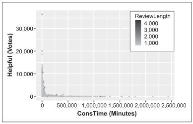

NOTE: figure/graphic rendered as an image from the PDF; its content is not machine-readable text. Caption (if any) follows as the next block.

#### Model

We model the helpfulness of an individual review using a fixed-effects model. Since the dependent variable, the number of helpful votes, is a count measure, we log-transformed it to make it compatible with the near-normal assumption. Alternative model specifications are explored in the robustness tests.

Similarly, since our independent variable, ConsTime, measured as the number of minutes played at the time of review, is a count measure, we also log-transformed it before using it in the model to reduce the possible influence of extreme outliers. To investigate possible nonlinear relationships between consumption time and helpful votes, we include a quadratic term of consumption time.

Temporal patterns associated with factors such as seasonal promotions and website traffic could influence the model’s effects (Sunder, Kim, and Yorkston 2019). We therefore introduce month-and-year fixed effects to our regression models. To account for game-specific characteristics, we include the fixed effects of games. Since reviews of the same game may be correlated, we consider clustered standard errors within reviews of the same game to prevent overestimation (e.g., Tan, Chandukala, and Reddy 2022; Tucker 2014). The basic model is

ln (Helpfulij + 1) = α0 × ln (ConsTimeij + 1) + β0

× ln (ConsTimeij + 1)<sup>2</sup> + GameFEj

+ MonthYearFEij + ϵij, (1)

where subscript ij represents reviewer-game level measures, GameFEj represents the fixed effect of game j, MonthYearFEij represents the fixed effect of month and year for the review

posted by reviewer i for game j, and ϵij represents the error term. The pair of coefficients α0 and β0 depicts the relationship between ConsTime and Helpful on the log-log scale.

Further, we include the moderators and their interactions with the ConsTime terms to investigate how the relationship between ConsTime and Helpful changes when considering these factors. We include the experience-signaling moderators ReviewLength, Separate, and their interaction, and include their interaction with both ConsTime and its quadratic term. We also include a product-level moderator, Free2Play, and incorporate its interactions with ConsTime in a similar way. All moderators (namely, ReviewLength, Separate, and Free2Play) are centered and scaled before fitting the model to help with interpretability and model convergence. While we use interaction terms to investigate and report the moderating effects for the main results, we also explore alternative ways to test the moderators in the robustness tests. Our full model may be written as

ln (Helpfulij + 1) = α0 × ln (ConsTimeij + 1)

+ β0 × ln (ConsTimeij + 1)<sup>2</sup>

+ γ1 × ln(ReviewLengthij + 1)

+ α1 × ln(ReviewLengthij + 1)

× ln (ConsTimeij + 1)

+ β1 × ln(ReviewLengthij + 1)

× ln (ConsTimeij + 1)<sup>2</sup> + γ2 × Separateij + α2 × Separateij

× ln (ConsTimeij + 1) + β2 × Separateij

× ln (ConsTimeij + 1)<sup>2</sup>

+ γ3 × ln(ReviewLengthij + 1)

× Separateij + α3 × ln(ReviewLengthij + 1)

× Separateij × ln (ConsTimeij + 1)

+ β3 × ln(ReviewLengthij + 1)

× Separateij × ln (ConsTimeij + 1)<sup>2</sup>

+ γ4 × Free2Playj + α4

× Free2Playj × ln(ConsTimeij + 1)

+ β4 × Free2Playj × ln (ConsTimeij + 1)<sup>2</sup>

+ μij + GameFEj + MonthYearFEij + ϵij,

(2)

where subscript j represents product-level characteristics, and μij represents the vector of all control variables described in the “Control variables” section. Coefficient pairs αk and βk (k = 1, 2, 3, 4) depict the moderators’ effects on the relationship between ConsTime and Helpful.

Figure 2. Model-Free Evidence.

Zhang et al. 97

Page 8

#### Results

Table 2 presents our main results. In Part 1, we examine review helpfulness as a function of a reviewer’s consumption time. In Part 2, we examine the moderating effects of review and product-level characteristics. In each part, we list two different versions of the model: Model A excludes control variables, and Model B includes them. Both models include game and monthyear fixed effects.

#### Estimation Results and the Main Effects

Model 1A shows that consumption time has a significant U-shaped association with helpful votes (α0 = −.194, β0 = .014, p < .001). Model 1B shows that these results hold when control variables are added (α0 = −.120, β0 = .009, p < .001), supporting H1. The results remain consistent after adding moderators and controls in the following models (i.e., Models 2A and 2B). Figure 3 visualizes this relationship based on Model 2B. We can see that the main effects form a U-shaped association between consumption time and helpfulness, indicating that lower consumption time is associated with more helpful votes. As consumption time increases, the number of votes decreases before increasing again.

#### Moderating Effects

We consider that two ways in which a reviewer’s experience is signaled can further impact the link between consumption time and review helpfulness: The reviewer’s experience can be signaled via review length and by the platform via the separated display of consumption time at review. Figure 4 visualizes these estimates, where solid (dashed) lines depict long (short) reviews and lines with (without) dots depict reviews after (before) Steam separated the display of consumption time between that at review and total time. We see that review length positively moderates the U-shaped association between consumption time and review helpfulness, supporting H2a. We also see that separate display of consumption time at review positively moderates the U-shaped association, supporting H2b. In addition, we see that the positive moderation of review length is greater after Steam separated consumption time between that at review and total consumption time, supporting H2c.

We next test whether the monetary costs of games each moderate the relationship between displayed consumption time and review helpfulness. Figure 5 depicts the moderating effect of games’ monetary costs, which shows that the U-shaped curve for high-cost games generally has a higher level of expected helpful votes, supporting H3.

Table 1. Descriptive Statistics.

[output not shown]

NOTE: table converted from PDF layout to HTML text; cell boundaries are reconstructed. See PDF if exact alignment matters.

98 Journal of Marketing 90(1)

Page 9

Table 2. Displayed Consumption Time Has a U-Shaped Association with Helpful Votes.

|  |  | Part1:MainEffects |  | Part2:Moderators |
| --- | --- | --- | --- | --- |
| DV=Ln(Helpful+1) | Hypothesis | Model1A | Model1B | Model2A Model2B |
| Ln(ConsTime+1) | H 1 | 194*** −. | 120*** −. | 188*** 134*** −. −. |
|  |  | (010) . | (007) . | (008) (007) . . |
| Ln(ConsTime+1)2 |  | 014*** . | 009*** . | 013*** 010*** . . |
| Moderators |  | (001) . | (000) . | (001) (000) . . |
| Ln(ReviewLength+1) |  |  | 103*** . | 270*** 195*** . . |
|  |  |  | (004) . | (020) (017) . . |
| Ln(ReviewLength+1)×Ln(ConsTime+1) | H 2a |  |  | 041*** 026*** −. −. |
|  |  |  |  | (006) (005) . . |
| Ln(ReviewLength+1)×Ln(ConsTime+1)2 |  |  |  | 003*** 002*** . . |
|  |  |  |  | (000) (000) . . |
| Separate |  |  | 039 −. | 050 082** . . |
|  |  |  | (027) . | (033) (030) . . |
| Separate×Ln(ConsTime+1) | H 2b |  |  | 028*** 034*** −. −. |
|  |  |  |  | (005) (004) . . |
| Separate×Ln(ConsTime+1)2 |  |  |  | 002*** 002*** . . |
|  |  |  |  | (000) (000) . . |
| Ln(ReviewLength+1)×Separate |  |  |  | 030* 048*** . . |
|  |  |  |  | (013) (010) . . |
| Ln(ReviewLength+1)×Separate×Ln(ConsTime+1) | H 2c |  |  | 012** 015*** −. −. |
|  |  |  |  | (004) (003) . . |
| Ln(ReviewLength+1)×Separate×Ln(ConsTime+1)2 |  |  |  | 001** 001*** . . |
|  |  |  |  | (000) (000) . . |
| Free2Play |  |  | 070*** −. | 026 146*** −. −. |
|  |  |  | (011) . | (036) (019) . . |
| Free2Play×Ln(ConsTime+1) | H 3 |  |  | 027*** 022*** . . |
|  |  |  |  | (006) (005) . . |
| Free2Play×Ln(ConsTime+1)2 |  |  |  | 002*** 001*** −. −. |
| Controls |  |  |  | (000) (000) . . |
| Ln(WeeksSinceRelease+1) |  |  | 023*** −. | 023*** −. |
|  |  |  | (006) . | (006) . |
| Similarity |  |  | 246*** −. | 249*** −. |
|  |  |  | (033) . | (031) . |
| Sentiment |  |  | 109*** −. | 109*** −. |
|  |  |  | (008) . | (008) . |
| Subjectivity |  |  | 025*** −. | 024*** −. |
|  |  |  | (004) . | (004) . |
| Specificity |  |  | 062*** . | 062*** . |
|  |  |  | (005) . | (005) . |
| Weekend |  |  | 000 . | 000 . |
|  |  |  | (002) . | (002) . |
| Ln(NReplies+1) |  |  | 888*** . | 886*** . |
|  |  |  | (015) . | (015) . |
| Ln(NGames+1) |  |  | 010*** . | 010*** . |
|  |  |  | (001) . | (001) . |
| Ln(NReviews+1) |  |  | 033*** . | 033*** . |
|  |  |  | (001) . | (001) . |
| Ln(NBadges+1) |  |  | 017*** . | 017*** . |
|  |  |  | (001) . | (001) . |
| Ln(NFriends+1) |  |  | 003*** −. | 003*** −. |
|  |  |  | (000) . | (000) . |
|  |  |  |  | (continued) |

NOTE: table converted from PDF layout to HTML text; cell boundaries are reconstructed. See PDF if exact alignment matters.

Zhang et al. 99

Page 10

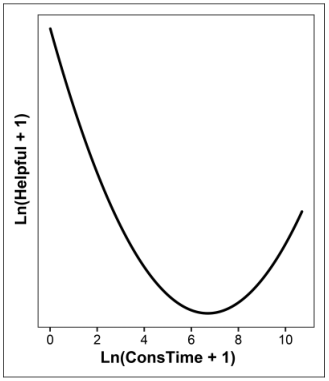

NOTE: figure/graphic rendered as an image from the PDF; its content is not machine-readable text. Caption (if any) follows as the next block.

#### Mechanism: Why Displayed Consumption Time in Reviews May Be Related to Helpful Votes

Expectations provide a potential explanation for why displayed consumption time in reviews may differentially impact consumer evaluations of reviews. Displaying the amount of time a reviewer interacted with a product can help consumers calibrate how helpful they expect the review will be, with shorter times engendering low expectations and longer times higher ones. Because low expectations are easy to surpass, consumers may find evaluations from reviewers with shorter consumption times to be more informative than expected. Higher expectations are harder to meet, which can lead consumers to be underwhelmed by evaluations from reviewers who spent more time with a product. The higher expectations that will also be

engendered by extended consumption times may be overcome, however, by beliefs that reviewers with extensive product engagement are more informed than those with short and moderate consumption times.

We provide preliminary support for this context-based account using consumers’ ability to emphasize reviews with an award. Specifically, consumers can use the points they earn from activities on Steam to emphasize a review with an award, which is publicly displayed on the review. Reviewers are notified when they receive an award and its gift of points, but the identity of awarders is kept anonymous. Reviews that exceed consumer expectations should be more likely to be associated with an award indicating the review was helpful than reviews that do not. We believe this provides supporting evidence because while helpful votes are “free,” the awards are associated with nonnegligible costs.

We test this possibility by examining the moderating effect of the “Extra Helpful” award that consumers can give to reviews. Steam describes the “Extra Helpful” award with the tagline “If this were any more helpful, I wouldn’t need a brain,” explaining that the real meaning is “I found this to be very helpful” and instructing consumers to give this award “when you want to say it simply: ‘I found this to be very helpful.’ No frills. Easy.”

Similar to our main analysis, to model the number of “Extra Helpful” awards received, we first take the ln(n + 1) transformation and then standardize it (centered and scaled) before modeling its interaction.<sup>1</sup> Table 3 presents the results, and the moderating effect is visualized accordingly in Figure 6. We can see that the “Extra Helpful” review awards positively moderate the U-shaped relationship between ConsTime and Helpful

Table 2. (continued)

|  |  | Part1:MainEffects |  | Part2:Moderators |
| --- | --- | --- | --- | --- |
| DV=Ln(Helpful+1) | Hypothesis | Model1A | Model1B | Model2A Model2B |
| GroupCons |  |  | 564*** . | 555*** . |
|  |  |  | (046) . | (047) . |
| Time2Beat |  |  | 016*** −. | 015*** −. |
|  |  |  | (003) . | (003) . |
| GameIDfixedeffects |  | Yes | Yes | Yes Yes |
| Month -year fixed effects |  | Yes | Yes | Yes Yes |
| Observations |  | 6867670 , , | 6867670 , , | 6867670 6867670 , , , , |
| R2 |  | 092 . | 221 . | 124 222 . . |

NOTE: table converted from PDF layout to HTML text; cell boundaries are reconstructed. See PDF if exact alignment matters.

*p < .05. **p < .01. ***p < .001. Notes: Standard errors (clustered at the game level) are in parentheses.

Figure 3. Consumption Time Follows a U-Shaped Association with Helpful Votes.

1 Since the awarding system is fairly new, having begun on November 20, 2020, we only focus on games that were released in 2021 and 2022 when we check whether the displayed consumption time has a U-shaped association with “Extra Helpful” review awards. In other words, all the playtime at review was separately displayed (i.e., Separate = 1) in this mechanism analysis. This also reduces our sample size.

100 Journal of Marketing 90(1)

Page 11

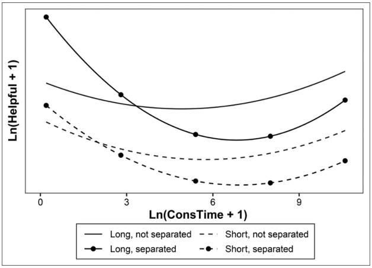

NOTE: figure/graphic rendered as an image from the PDF; its content is not machine-readable text. Caption (if any) follows as the next block.

votes, providing preliminary support for our expectation account as a potential mechanism.

#### Robustness Analysis

To furnish further evidence for our findings, we conduct robustness checks including matching-based inference, subsample analyses, alternative ways to investigate moderators, and alternative variable considerations.

#### Sample Matching

While our analysis included a range of control variables and fixed effects to account for known factors regarding the relationship between consumption time and perceived helpfulness, unobserved factors may still confound our findings. One possible confounder may derive from self-selection bias. To account for this, we run our analysis using matched samples (Web Appendix C reports the results). Since product consumption time is a continuous variable, we approached sample matching in two ways: by using an entropy matching technique specifically designed for continuous treatment (Tübbicke 2023), and by discretizing the consumption time into high, medium, and low groups before applying propensity score matching. Both approaches support a U-shaped association between consumption time and the perceived helpfulness of a review.

#### Subsample Considerations

We also checked whether our results hold when using a subsample by adopting alternative data handling decisions (Web Appendix D reports the results). First, we dropped reviews from those who received the game for free or did not purchase the game on Steam. Second, we dropped reviews posted before Steam started displaying the consumption time at the time of review separately from the total consumption time. Third, we dropped outliers with an extremely large ConsTime. Finally, to ensure the results are not dominated by the most popular games, we took a stratified subsample of all data by randomly selecting 500 reviews per game. In all these robustness tests, the results were consistent, showing a U-shaped association between consumption time and the perceived helpfulness of a review.

Alternative moderator model specification. Instead of investigating the moderating effects using interaction terms, we divided our samples into subgroups by each moderator (cutting at its median value if it is continuous) and fit our model by group separately. We ran these tests for each of our moderators (i.e., ReviewLength, Separate, and Free2Play), and the results are consistent (see Web Appendix E).

Alternative variable considerations. First, we considered alternative operationalizations of our dependent and independent variables (see Web Appendix F), including not log-transforming the dependent or independent variable, and dropping reviews without any helpful votes. Second, we also considered different settings of control variables (see Web Appendix G), including when

Figure 4. The Moderating Effects of Experience Signaling.

Zhang et al. 101

Page 12

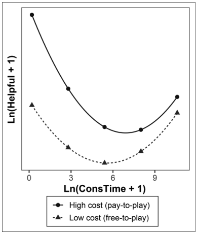

NOTE: figure/graphic rendered as an image from the PDF; its content is not machine-readable text. Caption (if any) follows as the next block.

controlling for whether the review was modified, controlling for whether the review had a nonzero number of helpful votes, controlling for the number of levels the reviewer had achieved, and using different combinations of badges, friends, and levels as control variables. The findings remain consistent for all these robustness tests.

Finally, we also conducted the mechanism analysis by subgroup (see Web Appendix H). Instead of using an interaction term between whether the review received an “Extra Helpful” award and ConsTime, we fit our model by subgroups of those with versus without an award. The results remain consistent.

#### Discussion

Does displaying the amount of time a reviewer interacted with a product prior to reviewing it translate to more helpful votes? Findings from video game reviews reveal that both low and high amounts of consumption time are associated with more helpful votes, while intermediate times are associated with fewer votes. Displayed consumption time may help consumers calibrate their expectations of review helpfulness and assess reviews accordingly. Moderation evidence related to review and product factors and preliminary mechanism evidence related to consumer gifts of review awards provide support for this context-based expectations account.

#### Theoretical Implications

We add to studies that examine the link between reviewer experience and persuasion (Nguyen et al. 2021; Packard and Berger 2017; Rocklage and Fazio 2020) by focusing on a temporal

Figure 5. The Moderating Effects of Game Cost.

Table 3. The Number of “Extra Helpful” Review Awards Moderates the Relationship Between Displayed Consumption Time and Review Helpfulness.

|  | DV=Ln(Helpful+1) | “ExtraHelpful” ReviewAward |
| --- | --- | --- |
| Ln(ConsTime+1) |  | 145*** −. |
|  |  | (011) . |
|  | Ln(ConsTime+1)2 | 010*** . |
|  |  | (001) . |
|  | Ln(ExtraHelpfulAward+1) | 159*** . |
|  |  | (013) . |
|  | Ln(ExtraHelpfulAward+1)×Ln(ConsTime+1) | 011** . |
|  |  | (004) . |
|  | Ln(ExtraHelpfulAward+1)×Ln(ConsTime+1)2 | 001*** −. |
|  |  | (000) . |
|  | Ln(ReviewLength+1) | 180*** . |
|  |  | (021) . |
|  | Ln(ReviewLength+1)×Ln(ConsTime+1) | 026*** −. |
|  |  | (007) . |
|  | Ln(ReviewLength+1)×Ln(ConsTime+1)2 | 001*** . |
|  |  | (001) . |
|  | Free2Play | 109*** −. |
|  |  | (028) . |
|  | Free2Play×Ln(ConsTime+1) | 021* . |
|  |  | (008) . |
|  | Free2Play×Ln(ConsTime+1)2 | 001* −. |
|  |  | (001) . |
|  | Ln(WeeksSinceRelease+1) | 031** −. |
|  | Similarity | (010) . 220*** −. |
|  |  | (052) . |
|  | Sentiment | 123*** −. |
|  |  | (013) . |
|  | Subjectivity Specificity Weekend | 013* −. (005) . 069*** . (008) . 002 . |
|  |  | (003) . |
|  | Ln(NReplies+1) | 681*** . |
|  |  | (020) . |
|  | Ln(NGames+1) | 011*** . (001) . |
|  | Ln(NReviews+1) | 029*** . |
|  | Ln(NBadges+1) Ln(NFriends+1) | (001) . 015*** . (001) . 003*** −. (001) . |
|  | GroupCons | 417*** . |
|  |  | (037) . |
|  | Time2Beat | 002*** −. |
|  | GameIDfixedeffects Month -year fixed effects | (001) . Yes Yes |
|  | Observations | 3239190 , , |
|  | R2 | 256 . |

NOTE: table converted from PDF layout to HTML text; cell boundaries are reconstructed. See PDF if exact alignment matters.

*p < .05. **p < .01. ***p < .001. Notes: Standard errors (clustered at the game level) are in parentheses.

102 Journal of Marketing 90(1)

Page 13

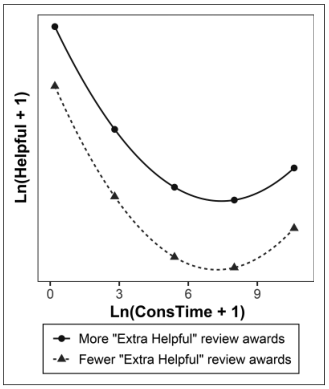

NOTE: figure/graphic rendered as an image from the PDF; its content is not machine-readable text. Caption (if any) follows as the next block.

factor of product experience. Whereas past studies leverage tangential measures of reviewer experience such as the number of reviews written or products purchased, the displayed amount of time reviewers spent interacting with the reviewed product directly relates to the product and is a more relevant indicator of reviewers’ evaluation basis. In addition, while prior studies treat reviewers as either experts or not, our continuous approach to reviewer experience better captures how it may relate to consumer perceptions of review helpfulness.

Our finding that the link between displayed consumption time and helpful votes follows a U-shaped curve helps clarify the nuances of this practice. It also helps reconcile the mixed findings of recent studies that show how beliefs that a reviewer is an expert can increase review persuasiveness in some instances (Packard and Berger 2017; Wu, Jin, and Xu 2021) but induce negative connotations that decrease persuasiveness in other instances (Yazdani, Gopinath, and Carson 2018). Our work suggests these differences mayrelatetothedegreetowhichreviewhelpfulnessmeetsconsumer expectations.

#### Implications for Review Platforms

As online reviews continue mushrooming, platforms have implemented strategies to help consumers parse them. Displaying how long a reviewer interacted with a product can help reduce asymmetric information (e.g., Ludwig et al. 2022) by providing context for a reviewer’s evaluation basis. Because platforms may be unaware of consumer needs, displayed consumption time could also facilitate better matches between consumers and reviews. For instance, matching reviews with consumers by consumption similarity could better suit consumers’ information needs. Nintendo exemplified this by requesting reviewers to identify the type of consumer they are (casual vs. core). Managing consumer expectations of

review helpfulness could thus help platforms decrease disappointment and increase satisfaction.

Because experience with the reviewed product may not always garner helpful votes, platforms may be strategic about whom to seek feedback from, how to incentivize reviews, and the review guidelines they provide. Context-based expectations provide a possible explanation. Intermediate amounts of consumption time may boost consumer expectations of review helpfulness, which may be hard to meet. Platforms could encourage reviewers with more consumption time to provide more information to meet the higher bar that their experience sets. Our findings also support immediately soliciting feedback, as doing so can increase helpful votes (e.g., Jung et al. 2023). We further suggest that when firms should solicit feedback may depend on factors including the product cost.

#### Avenues for Future Research

Although our findings come from a video game platform where consumption time is easy to log, consumer unawareness of a reviewer’s evaluation basis is a common problem for review platforms. While our results may not generalize to offline-use products whose consumption time is harder for platforms to capture, encouraging reviewers to report consumption time could assuage this concern. In addition, while our analysis focuses on hedonic experiences for which individuals’ quality perceptions may differ, future studies may probe whether our findings hold for other product types.

Acknowledgments

The authors thank Panos Adamopoulos, Kelly Hewett, Vamsi K. Kanuri, Qing Liu, Vilma Todri, Morgan K. Ward, and the JM review team for feedback on prior versions of this article.

Coeditor

Shrihari Sridhar

Associate Editor

Jacob Goldenberg

Declaration of Conflicting Interests

The author(s) declared no potential conflicts of interest with respect to the research, authorship, and/or publication of this article.

Funding

The author(s) received no financial support for the research, authorship, and/or publication of this article.

ORCID iDs

Zheng Zhang https://orcid.org/0000-0001-6914-0050 Wenjun Zhou https://orcid.org/0000-0003-2346-8151 Michelle Andrews https://orcid.org/0009-0009-6834-273X

Figure 6. The Moderating Effect of “Extra Helpful” Review Awards.

Zhang et al. 103

Page 14

References

Abell, Annika, Carter Morgan, and Marisabel Romero (2024), “The

Power of a Star Rating: Differential Effects of Customer Rating Formats on Magnitude Perceptions and Consumer Reactions,” Journal of Marketing Research, 61 (6), 1041–57. Akbarabadi, Mina and Monireh Hosseini (2020), “Predicting the

Helpfulness of Online Customer Reviews: The Role of Title Features,” International Journal of Market Research, 62 (3), 272–87. Alba, Joseph W. and J. Wesley Hutchinson (1987), “Dimensions of

Consumer Expertise,” Journal of Consumer Research, 13 (4), 411–54. Baker, Kristen (2022), “Why Customer Reviews and Testimonials

Convert: Research-Backed Insights,” HubSpot (May 18), https:// blog.hubspot.com/service/customer-reviews-testimonials. Broekhuijsen, Niels (2019), “Steam Wants Gamers to Review Their

Reviews After Longer Playtime,” Tom’s Hardware (October 30), https://www.tomshardware.com/news/steam-asking-update-gamereviews-longer-playtime. Ceylan, Gizem, Kristin Diehl, and Davide Proserpio (2024), “Words

Meet Photos: When and Why Photos Increase Review Helpfulness,” Journal of Marketing Research, 61 (1), 5–26. Chase, William G. and Herbert A. Simon (1973), “Perception in

Chess,” Cognitive Psychology, 4 (1), 55–81. Chen, Pei-Yu (Sharon) and Lorin M. Hitt (2002), “Measuring

Switching Costs and the Determinants of Customer Retention in Internet-Enabled Businesses: A Study of the Online Brokerage Industry,” Information Systems Research, 13 (3), 255–74. Chen, Yubo and Jinhong Xie (2008), “Online Consumer Review:

Word-of-Mouth as a New Element of Marketing Communication Mix,” Management Science, 54 (3), 477–91. Craciun, Georgiana, Wenqi Zhou, and Zhe Shan (2020), “Discrete

Emotions Effects on Electronic Word-of-Mouth Helpfulness: The Moderating Role of Reviewer Gender and Contextual Emotional Tone,” Decision Support Systems, 130, 113226. Entertainment Software Association (2020), “U.S. Video Game

Content Generated $35.4 Billion in Revenue for 2019,” press release (January 24), https://www.theesa.com/u-s-video-gamecontent-generated-35-4-billion-in-revenue-for-2019/. Ghose, Anindya and Panos Ipeirotis (2011), “Estimating the Helpfulness and Economic Impact of Product Reviews: Mining Text and Reviewer Characteristics,” IEEE Transactions on Knowledge and Data Engineering, 23 (10), 1498–512. Gilly, Mary C., John L. Graham, Mary Finley Wolfinbarger, and Laura

J. Yale (1998), “A Dyadic Study of Interpersonal Information Search,” Journal of the Academy of Marketing Science, 26 (2), 83–100. Honnibal, Matthew, Ines Montani, Sofie Van Landeghem, and

Adriane Boyd (2020), “spaCy: Industrial-Strength Natural Language Processing in Python,” https://doi.org/10.5281/zenodo. 1212303. Hope, Ole-Kristian, Danqi Hu, and Hai Lu (2016), “The Benefits of

Specific Risk-Factor Disclosures,” Review of Accounting Studies, 21, 1005–45. Hoskins, Jake, Shyam Gopinath, J. Cameron Verhaal, and Elham Yazdani (2021), “The Influence of the Online Community,

Professional Critics, and Location Similarity on Review Ratings for Niche and Mainstream Brands,” Journal of the Academy of Marketing Science, 49, 1065–87. Hu, Nan, Ling Liu, and Jie Jennifer Zang (2008), “Do Online Reviews

Affect Product Sales? The Role of Reviewer Characteristics and Temporal Effects,” Information Technology Management, 9, 201–14. Johnson, Kathy E. and Carolyn B. Mervis (1997), “Effects of Varying

Levels of Expertise on the Basic Level of Categorization,” Journal of Experimental Psychology: General, 126 (3), 248–77. Jung, Miyeon, Sunghan Ryu, Sang Pil Han, and Daegon Cho (2023),

“Ask for Reviews at the Right Time: Evidence from Two Field Experiments,” Journal of Marketing, 87 (4), 528–49. Kim, Jong Min and Jeongsoo Han (2022), “Impact of the Length of

Stay at Hotels on Online Reviews,” International Journal of Contemporary Hospitality Management, 34 (4), 1249–69. Kübler, Raoul V., Lara Lobschat, Lina Welke, and Hugo van der Meij

(2024), “The Effect of Review Images on Review Helpfulness: A Contingency Approach,” Journal of Retailing, 100 (1), 5–23. Li, Linyi, Shyam Gopinath, and Stephen J. Carson (2022), “History

Matters: The Impact of Online Customer Reviews Across Product Generations,” Management Science, 68 (5), 3878–903. Loria, Steven (2021), “TextBlob: Simplified Text Processing,” Release

0.17.1, https://textblob.readthedocs.io/en/dev/. Ludwig, Stephan, Dennis Herhausen, Dhruv Grewal, Liliana Bove,

Sabine Benoit, Ko de Ruyter, and Peter Urwin (2022), “Communication in the Gig Economy: Buying and Selling in Online Freelance Marketplaces,” Journal of Marketing, 86 (4), 141–61. Lutz, Bernhard, Nicolas Pröllochs, and Dirk Neumann (2022), “Are

Longer Reviews Always More Helpful? Disentangling the Interplay Between Review Length and Line of Argumentation,” Journal of Business Research, 144, 888–901. Maheswaran, Durairaj (1994), “Country of Origin as a Stereotype:

Effects of Consumer Expertise and Attribute Strength on Product Evaluations,” Journal of Consumer Research, 21 (2), 354–65. Medin, Douglas L., Robert L. Goldstone, and Dedre Gentner (1993),

“Respects for Similarity,” Psychological Review, 100 (2), 254–78. Metzger, Miriam J., Andrew J. Flanagin, and Ryan B. Medders (2010),

“Social and Heuristic Approaches to Credibility Evaluation Online,” Journal of Communication, 60 (3), 413–39. Mousavi, Javad, Surendra N. Singh, Promothesh Chatterjee, and

Tamara Masters (2024), “Unveiling Stars: How Graphical Displays of Online Consumer Ratings Affect Consumer Perception and Judgment,” Journal of Marketing Research, 61 (2), 225–47. Mukherjee, Ashesh and Wayne D. Hoyer (2001), “The Effect of Novel

Attributes on Product Evaluation,” Journal of Consumer Research, 28 (3), 462–72. Ngo-Ye,Thomas L.andAtishP.Sinha(2014), “TheInfluenceof Reviewer

Engagement Characteristics on Online Review Helpfulness: A Text Regression Model,” Decision Support Systems, 61, 47–58. Nguyen, Peter, Xin (Shane) Wang, Xi Li, and June Cotte (2021),

“Reviewing Experts’ Restraint from Extremes and Its Impact on Service Providers,” Journal of Consumer Research, 47 (5), 654–74. Packard, Grant and Jonah Berger (2017), “How Language Shapes

Word of Mouth’s Impact,” Journal of Marketing Research, 54 (4), 572–88.

104 Journal of Marketing 90(1)

Page 15

Parry, Douglas A., Brittany I. Davidson, Craig J.R. Sewall, Jacob

T. Fisher, Hannah Mieczkowski, and Daniel S. Quintana (2021), “A Systematic Review and Meta-Analysis of Discrepancies Between Logged and Self-Reported Digital Media Use,” Nature Human Behaviour, 5, 1535–47. Raza, Abeer (2019), “Review Platforms: How to Attract Consumers by

Providing the Information They Want,” Forbes (June 26), https:// www.forbes.com/councils/theyec/2019/06/26/review-platformshow-to-attract-consumers-by-providing-the-information-they-want/. Ritov, Ilana (2000), “The Role of Expectations in Comparisons,”

Psychological Review, 107 (2), 345–57. Rocklage, Matthew D. and Russell H. Fazio (2020), “The Enhancing

Versus Backfiring Effects of Positive Emotion in Consumer Reviews,” Journal of Marketing Research, 57 (2), 332–52. Rocklage, Matthew D., Derek D. Rucker, and Loran F. Nordgren

(2021), “Emotionally Numb: Expertise Dulls Consumer Experience,” Journal of Consumer Research, 48 (3), 355–73. Stang, David J. (1975), “Effects of ‘Mere Exposure’ on Learning and

Affect,” Journal of Personality and Social Psychology, 31 (1), 7–12. Sun, Xinyu, Maoxin Han, and Juan Feng (2019), “Helpfulness of

Online Reviews: Examining Review Informativeness and Classification Thresholds by Search Products and Experience Products,” Decision Support Systems, 124, 113099. Sunder, Sarang, Kihyun Hannah Kim, and Eric A. Yorkston (2019),

“What Drives Herding Behavior in Online Ratings? The Role of Rater Experience, Product Portfolio, and Diverging Opinions,” Journal of Marketing, 83 (6), 93–112. Tan, Yong-Chin, Sandeep R. Chandukala, and Srinivas K. Reddy

(2022), “Augmented Reality in Retail and Its Impact on Sale,” Journal of Marketing, 86 (1), 48–66. Todri, Vilma, Panagiotis (Panos) Adamopoulos, and Michelle Andrews (2022), “Is Distance Really Dead in the Online World? The Moderating Role of Geographical Distance on the

Effectiveness of Electronic Word of Mouth,” Journal of Marketing, 86 (4), 118–40. Topaloglu, Omer and Mayukh Dass (2021), “The Impact of Online

Review Content and Linguistic Style Matching on New Product Sales: The Moderating Role of Review Helpfulness,” Decision Sciences, 52 (3), 749–75. Tübbicke, Stefan (2023), “ebct: Using Entropy Balancing for

Continuous Treatments to Estimate Dose–Response Functions and Their Derivatives,” Stata Journal, 23 (3), 709–29. Tucker, Catherine (2014), “Social Networks, Personalized Advertising, and Privacy Controls,” Journal of Marketing Research, 51 (5), 546–62. Varga, Marton and Paulo Albuquerque (2024), “The Impact of

Negative Reviews on Online Search and Purchase Decisions,” Journal of Marketing Research, 61 (5), 803–20. Weathers, Danny, Scott D. Swain, and Varun Grover (2015), “Can

Online Product Reviews Be More Helpful? Examining Characteristics of Information Content by Product Type,” Decision Support Systems, 79, 12–23. Wu, Xiaoyue, Liyin Jin, and Qian Xu (2021), “Expertise Makes

Perfect: How the Variance of a Reviewer’s Historical Ratings Influences the Persuasiveness of Online Reviews,” Journal of Retailing, 97 (2), 238–50. Yazdani, Elham, Shyam Gopinath, and Steve Carson (2018), “Preaching to the Choir: The Chasm Between Top-Ranked Reviewers, Mainstream Customers, and Product Sales,” Marketing Science, 37 (5), 838–51. Yin, Dezhi, Samuel D. Bond, and Han Zhang (2017), “Keep Your Cool

or Let It Out: Nonlinear Effects of Expressed Arousal on Perceptions of Consumer Reviews,” Journal of Marketing Research, 54 (3), 447–63. Zhang, Cong, Atish P. Sinha, and Yang Wang (2024), “When to Target

Customers for Helpful Reviews: The Evolution of Consumers’ Product Evaluations with Product Exposure,” Information Systems Frontiers, 26, 1183–99.

Zhang et al. 105

Page 16